# Factores de riesgo y tasa de letalidad por COVID-19 en aglomerados urbanos con 1 millón a 2 millones de habitantes

Agustín Nava - 2020

# 1 Introducción

En este trabajo me propongo a buscar si las variaciones en las medias de ciertos parametros de riesgo medidos en la Encuesta Nacional de Factores de Riesgo (2018) están relacionadas con los cambios en el indice de letalidad por COVID-19.

Para lograr cierta homogeneidad, me focalicé en los aglomerados urbanos cuya población superara el millón de habitantes pero que sea inferior a dos millones según el censo nacional del 2010. Esta selección no será dificil en caso de los datos presentados en la ENFR, no así con la base de datos COVID, ya que hay muchos registros que dejan el partido de origen sin especificar.

# 2 Exploración y transformación de bases

## 2.1 Cargo librerías y bases

```r
library(dplyr)
library(readxl)
library(readr)
library(tidyverse)
library(survey)
```

```r
Covid19Casos<- read_csv("Covid19Casos.csv")
enfr2018 <- readRDS("enfr2018rep.rds")
```

## 2.2 Base COVID

Luego de cargar los dataframes, me concentro en cada uno de ellos. Primero me quedo con los casos que correspondan a los aglomerados mencionados. Posteriormente, cuento la cantidad de *infectados y fallecidos*.

```r
gr <- c("Rosario", "San Lorenzo")
gm <- c("Las Heras", "Capital", "Guaymallén", "Godoy Cruz", "Luján de Cuyo", "Maipú")
gc <- c("Capital", "Colón", "Punilla", "Santa María", "Río Primero", "Río Segundo")
pv <- c("Córdoba", "Santa Fe", "Mendoza")

COVIDCASOS_AGLOM <- Covid19Casos %>%
  mutate(aglomerado = case_when(residencia_departamento_nombre %in% gr ~ "GRAN_ROSARIO",
                                  residencia_departamento_nombre %in% gm ~ "GRAN_MENDOZA",
                                  residencia_departamento_nombre %in% gc ~ "GRAN_CORDOBA")) %>%
  filter(!is.na(aglomerado)) %>%
  filter(residencia_provincia_nombre == pv) %>%
  group_by(aglomerado) %>%
  summarise(total_casos = sum(clasificacion_resumen == "Confirmado"))

COVIDTERAPIA_AGLOM <- Covid19Casos %>%
  mutate(aglomerado = case_when(residencia_departamento_nombre %in% gr ~ "GRAN_ROSARIO",
                                  residencia_departamento_nombre %in% gm ~ "GRAN_MENDOZA",
                                  residencia_departamento_nombre %in% gc ~ "GRAN_CORDOBA")) %>%
  filter(!is.na(aglomerado)) %>%
  filter(residencia_provincia_nombre == pv) %>%
  group_by(aglomerado) %>%
  summarise(total_fall = sum(fallecido == "SI"))

COVIDAGLOM <- left_join(COVIDCASOS_AGLOM,
                        COVIDTERAPIA_AGLOM,
                        by = "aglomerado")
```

Para finalizar, calculo la *tasa de letalidad según aglomerado*.

```r
COVIDAGLOM <- COVIDAGLOM %>%
  mutate(tasa = (total_fall/total_casos)*100)
```

```r
COVIDAGLOM
```

| aglomerado | total_casos | total_fall | tasa |
| --- | --- | --- | --- |
| GRAN_CORDOBA | 18245 | 212 | 1.161962 |
| GRAN_MENDOZA | 67119 | 1335 | 1.989005 |
| GRAN_ROSARIO | 55376 | 1041 | 1.879876 |

## 2.3 Base ENFR 2018

En esta parte seleccioné los datos que correspondían a los aglomerados de interes y luego indiqué el diseño de muestreo para utilizar la librería **survey**.

```r
  enfr_aglom <- enfr2018 %>%
    filter(aglomerado == '2' | aglomerado == '3' | aglomerado == '4') %>%
      mutate(aglomerado = case_when(aglomerado == 2 ~ "GRAN_CORDOBA",
                             aglomerado == 3 ~ "GRAN_ROSARIO",
                             aglomerado == 4 ~ "GRAN_MENDOZA",))

disenoaglom <- svrepdesign(data = enfr_aglom,
                       weights = ~wf2p,
                       repweights = "wf1p_rep[1-9]+",
                       type = "bootstrap",
                       mse = T)
```

Ya apartados los aglomerados de interés, comienzo a calcular las medias que presentan los datos que voy a utilizar. En este caso busqué tres valores que reflejaran la prevalencia de obesidad, diabetes e hipertensión. Los seleccionados fueron:

1. **Indice de masa corporal** agrupado según mediciones antropométricas ≥ 30.
2. **Glucemia** por autorreporte o medición bioquímica elevada.
3. **Presión alta** registrada por profesional de salud en más de una ocasión.

```r
IMCALTO_AGLOM <- svyby(~as.factor(imc_categorias_bima == 3), ~as.factor(aglomerado), disenoaglom, na = TRUE, svymean)

GLUCELEVAUTOREP_AGLOM <- svyby(~as.factor(prevalencia_glucemia_elevada_combinada == 1), ~as.factor(aglomerado), disenoaglom, na = TRUE, svymean)

DXHTA_AGLOM <- svyby(~as.factor(biha03 == 2), ~as.factor(aglomerado), disenoaglom, na = TRUE, svymean)

FR_AGLOM <- left_join(IMCALTO_AGLOM,
                      GLUCELEVAUTOREP_AGLOM,
                      by = "as.factor(aglomerado)") %>%
  left_join(DXHTA_AGLOM,
            by = "as.factor(aglomerado)") %>%
  rename("aglomerado" = "as.factor(aglomerado)",  "imcelev" = "as.factor(imc_categorias_bima == 3)TRUE", "glucelevautorep" = "as.factor(prevalencia_glucemia_elevada_combinada == 1)TRUE", "dxhta" = "as.factor(biha03 == 2)TRUE") %>%
  select(aglomerado, imcelev, glucelevautorep, dxhta)

FR_AGLOM
```

| aglomerado | imcelev | glucelevautorep | dxhta |
| --- | --- | --- | --- |
| GRAN_CORDOBA | 0.2690797 | 0.0906701 | 0.1824696 |
| GRAN_MENDOZA | 0.3277508 | 0.1859523 | 0.2077432 |
| GRAN_ROSARIO | 0.3245756 | 0.1243875 | 0.2059334 |

Por ultimo, combino ambas bases.

```r
COVID_FR_AGLOM <- left_join(COVIDAGLOM,
                      FR_AGLOM,
                      by = "aglomerado")
```

# 3 Regresiones

```r
rl_hta <-  lm(tasa ~ dxhta,
               COVID_FR_AGLOM)
summary(rl_hta)
```

```
##
## Call:
## lm(formula = tasa ~ dxhta, data = COVID_FR_AGLOM)
##
## Residuals:
##         1         2         3
##  0.001914  0.024816 -0.026730
##
## Coefficients:
##             Estimate Std. Error t value Pr(>|t|)
## (Intercept)  -4.6457     0.3646  -12.74   0.0499 *
## dxhta        31.8174     1.8319   17.37   0.0366 *
## ---
## Signif. codes:  0 '***' 0.001 '**' 0.01 '*' 0.05 '.' 0.1 ' ' 1
##
## Residual standard error: 0.03652 on 1 degrees of freedom
## Multiple R-squared:  0.9967, Adjusted R-squared:  0.9934
## F-statistic: 301.7 on 1 and 1 DF,  p-value: 0.03661
```

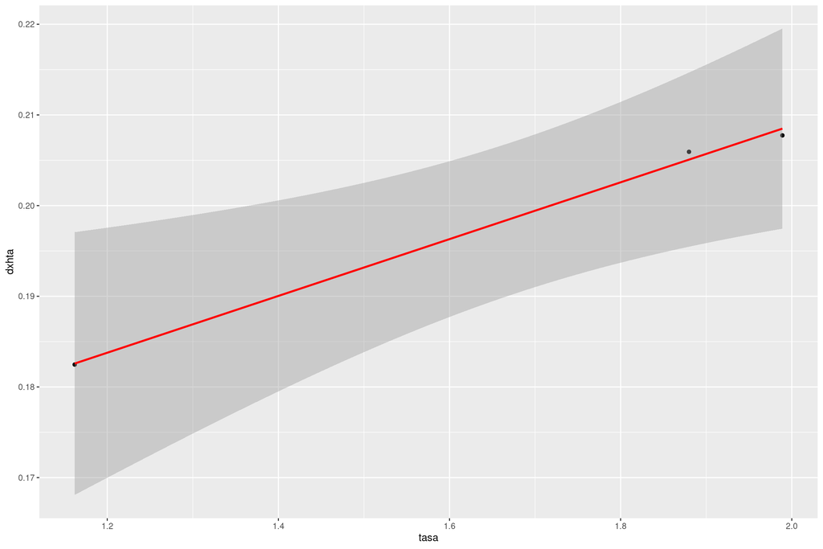

```r
ggplot(COVID_FR_AGLOM, aes(x = tasa, y = dxhta)) +
  geom_point() +
  stat_smooth(method = "lm", col = "red")
```

```r
rl_imc <-  lm(tasa ~ imcelev,
               COVID_FR_AGLOM)
summary(rl_imc)
```

```
##
## Call:
## lm(formula = tasa ~ imcelev, data = COVID_FR_AGLOM)
##
## Residuals:
##         1         2         3
##  0.001836  0.032086 -0.033922
##
## Coefficients:
##             Estimate Std. Error t value Pr(>|t|)
## (Intercept)  -2.4942     0.3088  -8.078   0.0784 .
## imcelev      13.5807     1.0014  13.561   0.0469 *
## ---
## Signif. codes:  0 '***' 0.001 '**' 0.01 '*' 0.05 '.' 0.1 ' ' 1
##
## Residual standard error: 0.04673 on 1 degrees of freedom
## Multiple R-squared:  0.9946, Adjusted R-squared:  0.9892
## F-statistic: 183.9 on 1 and 1 DF,  p-value: 0.04686
```

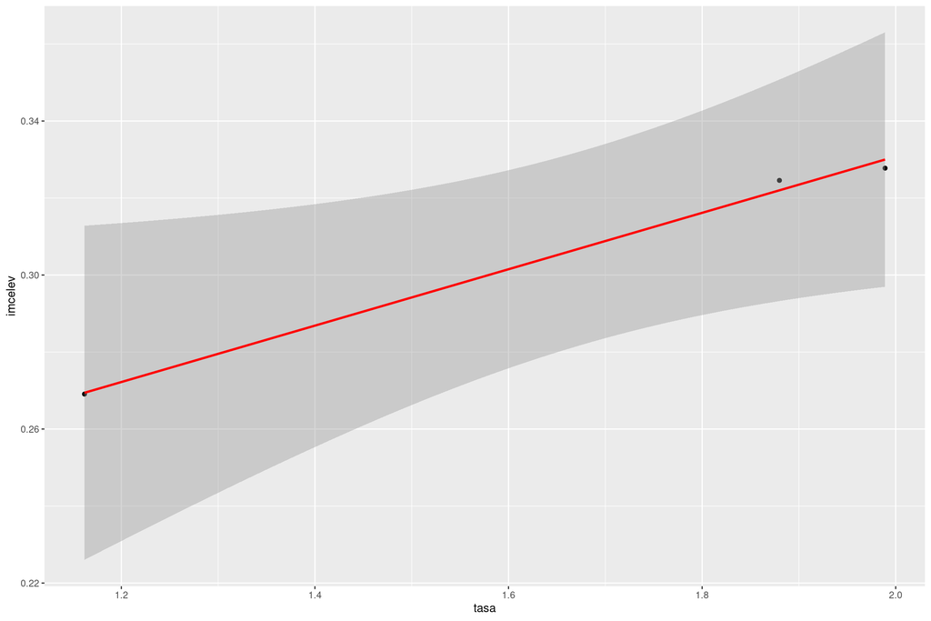

```r
ggplot(COVID_FR_AGLOM, aes(x = tasa, y = imcelev)) +
  geom_point() +
  stat_smooth(method = "lm", col = "red")
```

```r
rl_gluc <-  lm(tasa ~ glucelevautorep,
               COVID_FR_AGLOM)
summary(rl_gluc)
```

```
##
## Call:
## lm(formula = tasa ~ glucelevautorep, data = COVID_FR_AGLOM)
##
## Residuals:
##        1        2        3
## -0.17811 -0.09754  0.27565
##
## Coefficients:
##                 Estimate Std. Error t value Pr(>|t|)
## (Intercept)       0.6297     0.6984   0.902    0.533
## glucelevautorep   7.8344     5.0108   1.564    0.362
##
## Residual standard error: 0.3424 on 1 degrees of freedom
## Multiple R-squared:  0.7097, Adjusted R-squared:  0.4194
## F-statistic: 2.445 on 1 and 1 DF,  p-value: 0.3623
```

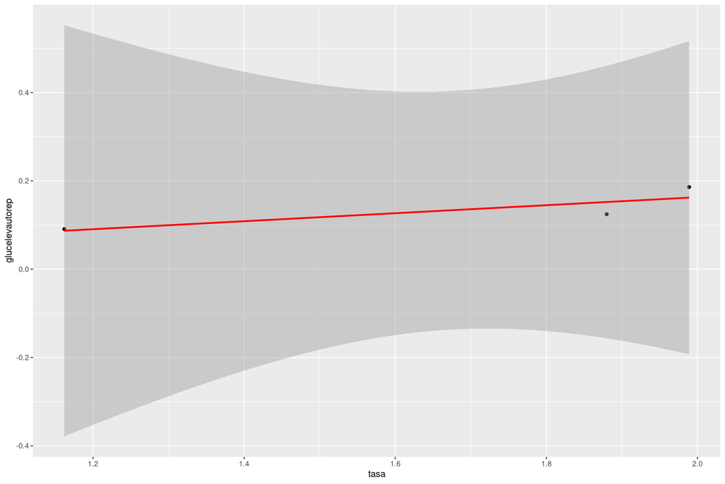

```r
ggplot(COVID_FR_AGLOM, aes(x = tasa, y = glucelevautorep)) +
  geom_point() +
  stat_smooth(method = "lm", col = "red")
```

# 4 Conclusión